# Assignment4

## Metropolis-Hastings

**Section 1**

Denote $\theta^\ast$ and $\theta^{(t-1)}$ as the proposed candidate and the old value, respectively. Let $J_t(x|y) = \beta(cy,c(c-y))$ be the jumping function, and $P(x)$ be the probability density function we need to sample on. The acceptance ratio is:

$$r = \frac{P(\theta^\ast)}{P(\theta^{(t-1)})} \frac{J_t(\theta^{(t-1)}|\theta^\ast)}{J_t(\theta^\ast|\theta^{(t-1)})}$$

Expanding the first factor using the formula for beta distribution gives:

$$r = \left(\frac{\theta^\ast}{\theta^{(t-1)}}\right)^{6-1} \left(\frac{1-\theta^\ast}{1-\theta^{(t-1)}}\right)^{4-1} \frac{J_t(\theta^{(t-1)}|\theta^\ast)}{J_t(\theta^\ast|\theta^{(t-1)})}$$

To implement the Metropolis-Hastings (MH) algorithm, we first initialize a vector for the draws. The first value of this vector is the starting value, which is generated from a uniform distribution between 0 and 1 (because beta distribution is only applicable for $0 \leq x \leq 1$). Then, we draw a new proposal $\theta^\ast$ candidate from $J_t$, and substitute it and the previous value $\theta^{(t-1)}$ in the vector into the formula for the acceptance ratio $r$. Finally, we accept $\theta^\ast$ with probability $\min(r,1)$, which can be done by an if condition. (Randomly generate a value between 0 and 1, and accept $\theta^\ast$ if this value is less than or equal to $\min(r,1)$; if not, we accept $\theta^{(t-1)}$.)

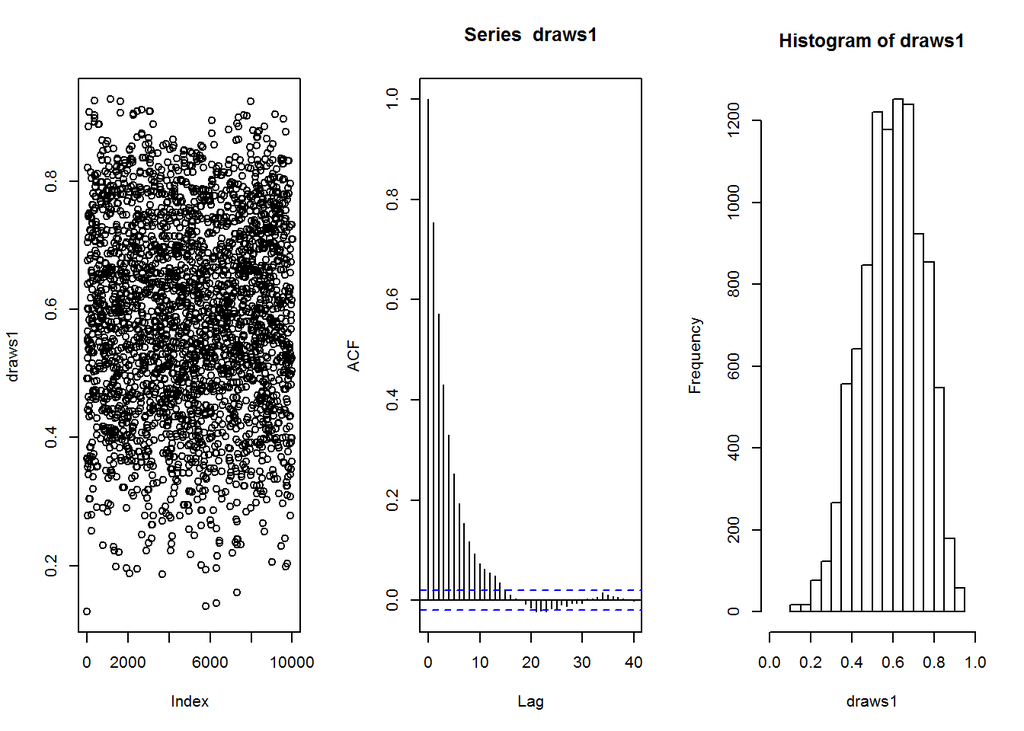

```r
#---------- Metropolis-Hastings sampling ----------#
myMH <- function(c, nIter, burnIn = 0){
  ### c: scaling factor
  ### nIter: number of iterations
  ### burnIn: discarded values of the chain

  chain <- numeric(nIter+1) # Initialize result vector
  chain[1] <- runif(1, min=0, max=1) # Randomly generate the starting value between 0 and 1

  for (ii in 1:nIter){
    # Draw new candidate from beta function
    x1 <- rbeta(1, shape1 = c*chain[ii], shape2 = c*(1-chain[ii]))

    # Acceptance ratio
    r <- (x1/chain[ii])^5*((1-x1)/(1-chain[ii]))^3*dbeta(chain[ii], shape1 = c*x1, shape2 = c*(1-x1))/dbeta(x1, shape1 = c*chain[ii], shape2 = c*(1-chain[ii]))

    if (runif(1, min=0, max=1) <= min(r,1)) {chain[ii+1] <- x1} else {chain[ii+1] <- chain[ii]}
  }

  # Get rid of burn in values
  if (burnIn > 0) {chain <- chain[-(1:burnIn)]}

  return(chain)
}

draws1 <- myMH(1,10000,0) # c = 1, no thinning

# Plot
par(mfrow=c(1,3))  #1 row, 3 columns
plot(draws1); acf(draws1); hist(draws1, xlim=c(0, 1))  #plot commands
```

**Section 2**

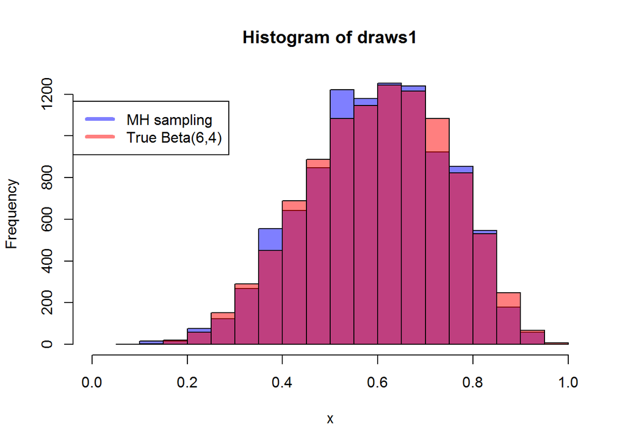

```r
#--------- Compare with beta(6,4) ----------#
draws.true <- rbeta(10000,6,4)
hist(draws1, xlim=c(0, 1), col = rgb(0,0,1,.5), xlab = "x")
hist(draws.true, col = rgb(1,0,0,.5), add = T)
legend("topleft", c("MH sampling", "True Beta(6,4)"), col=c(rgb(0,0,1,.5), rgb(1,0,0,.5)), lwd = 4, inset = c(0,0.1))
```

```r
#---------- Kolmogorov-Smirnov test c = 1 ----------#
ks.test(draws1,draws.true)
```

```
##
##  Two-sample Kolmogorov-Smirnov test
##
## data:  draws1 and draws.true
## D = 0.025433, p-value = 0.003102
## alternative hypothesis: two-sided
```

In a 2-sample K-S test, a high p-value (ie, more than 0.05) means the samples are drawn from the same distribution.

**Section 3**

We now perform the sampling with different c values (0.1, 1, 2.5, and 10) with 10000 draws and 5000 burn-ins.

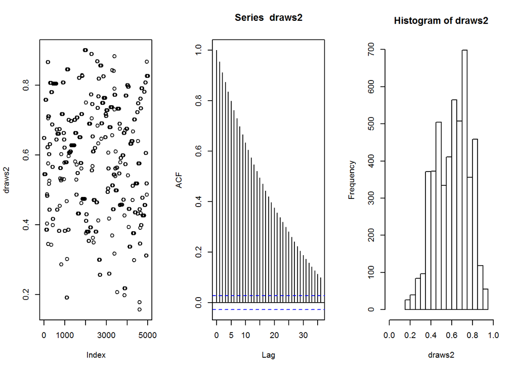

```r
#---------- Different sampling settings ----------#
draws1 <- myMH(1,10000,5000)
draws2 <- myMH(.1,10000,5000)
draws3 <- myMH(2.5,10000,5000)
draws4 <- myMH(10,10000,5000)

par(mfrow=c(1,3))  #1 row, 3 columns
plot(draws2); acf(draws2); hist(draws2, xlim=c(0, 1))  #plot commands
```

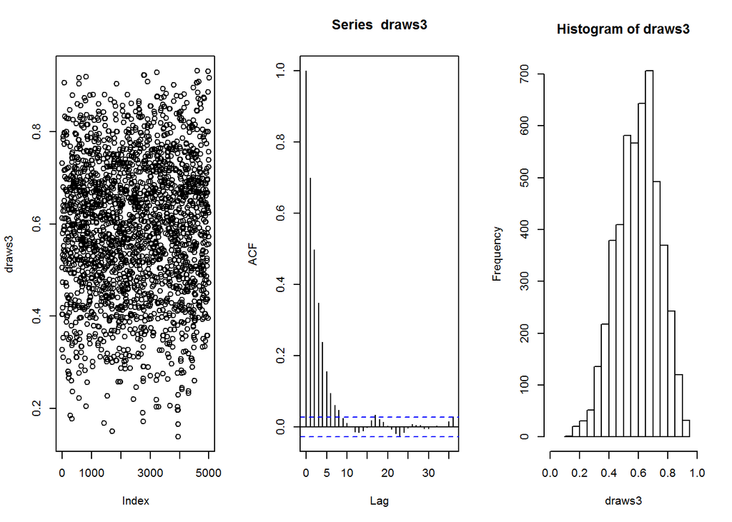

```r
par(mfrow=c(1,3))  #1 row, 3 columns
plot(draws3); acf(draws3); hist(draws3, xlim=c(0, 1))  #plot commands
```

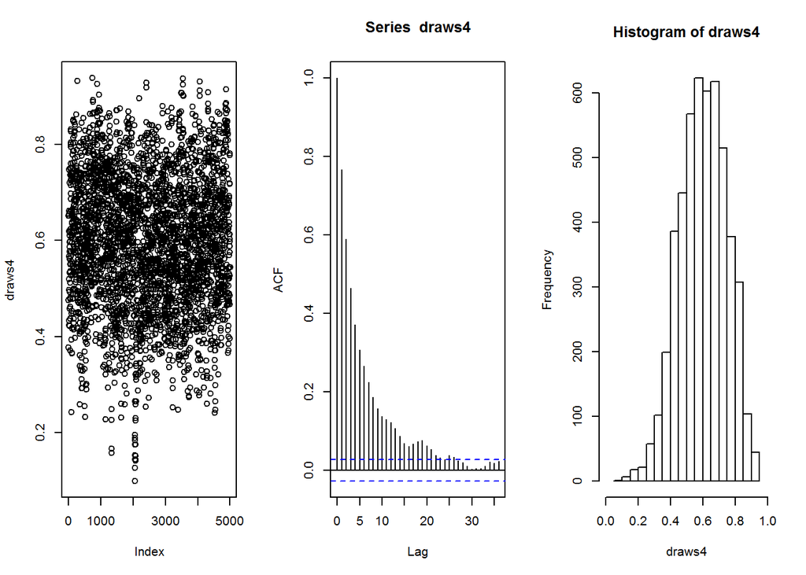

```r
par(mfrow=c(1,3))  #1 row, 3 columns
plot(draws4); acf(draws4); hist(draws4, xlim=c(0, 1))  #plot commands
```

To take into account the difference in the sampling size, we compare the samplers with the built-in beta distribution function in term of probability density instead of the frequency. The densities are shown below.

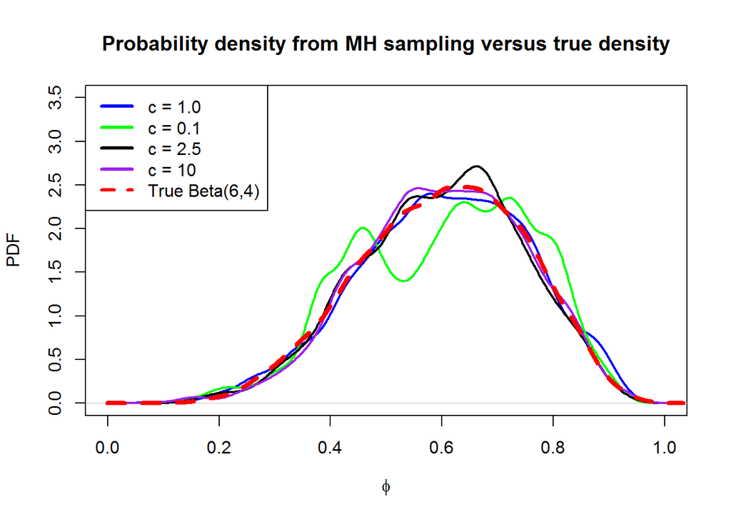

```r
## Compare histograms separately in term of probability density
plot(density(draws1), col = "blue", xlim=c(0, 1), ylim=c(0,3.5), main = "", xlab = expression(phi), ylab = "PDF", lwd = 2)
lines(density(draws2), col = "green", lwd = 2)
lines(density(draws3), col = "black", lwd = 2)
lines(density(draws4), col = "purple", lwd = 2)
lines(density(draws.true), col = "red", lwd = 4, lty = 2)
legend("topleft", c("c = 1.0","c = 0.1","c = 2.5","c = 10","True Beta(6,4)"), col=c("blue","green","black","purple","red"), lty = c(1,1,1,1,2), lwd = 3)
title(main = "Probability density from MH sampling versus true density")
```

```r
#---------- Kolmogorov-Smirnov test c = 1 ----------#
ks.test(draws1,draws.true)
```

```
##
##  Two-sample Kolmogorov-Smirnov test
##
## data:  draws1 and draws.true
## D = 0.02136, p-value = 0.09546
## alternative hypothesis: two-sided
```

```r
#---------- Kolmogorov-Smirnov test c = 0.1 ----------#
ks.test(draws2,draws.true)
```

```
##
##  Two-sample Kolmogorov-Smirnov test
##
## data:  draws2 and draws.true
## D = 0.063333, p-value = 4.858e-12
## alternative hypothesis: two-sided
```

```r
#---------- Kolmogorov-Smirnov test c = 2.5 ----------#
ks.test(draws3,draws.true)
```

```
##
##  Two-sample Kolmogorov-Smirnov test
##
## data:  draws3 and draws.true
## D = 0.026551, p-value = 0.01819
## alternative hypothesis: two-sided
```

```r
#---------- Kolmogorov-Smirnov test c = 10 ----------#
ks.test(draws4,draws.true)
```

```
##
##  Two-sample Kolmogorov-Smirnov test
##
## data:  draws4 and draws.true
## D = 0.019818, p-value = 0.1457
## alternative hypothesis: two-sided
```

We will now check the sampler with 100000 draws and 5000 burn-ins, which seem to be the optimal parameters. Here are the results of the K-S tests:

```r
#---------- Kolmogorov-Smirnov test c = 1 ----------#
draws1b <- myMH(1,100000,5000)
ks.test(draws1b,draws.true)
```

```
##
##  Two-sample Kolmogorov-Smirnov test
##
## data:  draws1b and draws.true
## D = 0.010714, p-value = 0.2501
## alternative hypothesis: two-sided
```

```r
#---------- Kolmogorov-Smirnov test c = 0.1 ----------#
draws2b <- myMH(.1,100000,5000)
ks.test(draws2b,draws.true)
```

```
##
##  Two-sample Kolmogorov-Smirnov test
##
## data:  draws2b and draws.true
## D = 0.032925, p-value = 6.052e-09
## alternative hypothesis: two-sided
```

```r
#---------- Kolmogorov-Smirnov test c = 2.5 ----------#
draws3b <- myMH(2.5,100000,5000)
ks.test(draws3b,draws.true)
```

```
##
##  Two-sample Kolmogorov-Smirnov test
##
## data:  draws3b and draws.true
## D = 0.0079916, p-value = 0.6101
## alternative hypothesis: two-sided
```

```r
#---------- Kolmogorov-Smirnov test c = 10 ----------#
draws4b <- myMH(10,100000,5000)
ks.test(draws4b,draws.true)
```

```
##
##  Two-sample Kolmogorov-Smirnov test
##
## data:  draws4b and draws.true
## D = 0.010814, p-value = 0.2405
## alternative hypothesis: two-sided
```

## Gibbs sampling

Marginal distribution:

$$p(x|y) = C_0 y e^{-yx}$$

First, we need to normalize $p(x,y)$ for $0<x<B$ to find $C_0$:

$$\int_0^B p(x,y)~dx = 1$$
$$\left.C_0 y \frac{e^{-yx}}{-y}\right|_{x=0}^{x=B} = 1$$
$$C_0 = \frac{1}{1-e^{-By}}$$

Next, we calculate the cumulative distribution function $P(x)$:

$$P(x) = \int_0^x p(t,y)~dt = \frac{1}{1-e^{-By}}(1-e^{-xy})$$

The inverse cumulative distribution function is:

$$x = P^{-1}(y) = -\frac{1}{y}\ln{\left[1-u(1-e^{-By})\right]}$$
where u is drawn from a uniform distribution between 0 and 1. Similarly:

$$y = P^{-1}(x) = -\frac{1}{x}\ln{\left[1-u(1-e^{-Bx})\right]}$$

The histogram plots for 500, 5000, 50000 samples are saved externally as `gibbs500.png`, `gibbs5000.png` and `gibbs50000.png`.

Expectations values were calculated as the mean of each chain, and they were shown at the end of the code.

```python
##### Import libraries
import numpy as np
import matplotlib.pyplot as plt

from math import *
from random import *

##### Define inverse CDF function for x|y
def CDF_xy(y, B = 5.0):
    P = uniform(0,1)
    x = -1/y*log(1 - P*(1-exp(-y*B)))
    return(x)

def myGibbs(T, B = 5.0):
    # Initialize a matrix of 2 columns for x and y
    chain = np.zeros((T,2))
    chain[0,0] = uniform(0,B)
    chain[0,1] = uniform(0,B)

    for ii in range(0,T-1):
        chain[ii+1,0] = CDF_xy(chain[ii,1], B)
        chain[ii+1,1] = CDF_xy(chain[ii,0], B)

    return(chain)

##### Sampling
# Set B = 5
myB = 5.0

# Sampling 500 points and plotting histogram
mychain = myGibbs(500, myB)
myx1 = mychain[:,0]


plt.hist(myx1, bins = np.linspace(0,myB,20))
plt.title("Gibbs sampling for 500 data points")
plt.xlabel("Value")
plt.ylabel("Frequency")
plt.savefig("gibbs500.png") # save figure externally

# Sampling 5000 points and plotting histogram
mychain = myGibbs(5000, myB)
myx2 = mychain[:,0]

plt.hist(myx2, bins = np.linspace(0,myB,20))
plt.title("Gibbs sampling for 5000 data points")
plt.xlabel("Value")
plt.ylabel("Frequency")
plt.savefig("gibbs5000.png") # save figure externally

#Sampling 50000 points and plotting histogram
mychain = myGibbs(50000, myB)
myx3 = mychain[:,0]


plt.hist(myx3, bins = np.linspace(0,myB,20))
plt.title("Gibbs sampling for 50000 data points")
plt.xlabel("Value")
plt.ylabel("Frequency")
plt.savefig("gibbs50000.png") # save figure externally

##### Expectation of x
print "Expectation from 500 samples is %.6f" % np.mean(myx1)
print "Expectation from 5000 samples is %.6f" % np.mean(myx2)
print "Expectation from 50000 samples is %.6f" % np.mean(myx3)
```

```
## Expectation from 500 samples is 1.275027
## Expectation from 5000 samples is 1.283397
## Expectation from 50000 samples is 1.263079
```

## K-Means

The k-mean classifier was written using Euclidean distance, and the codes are shown below:

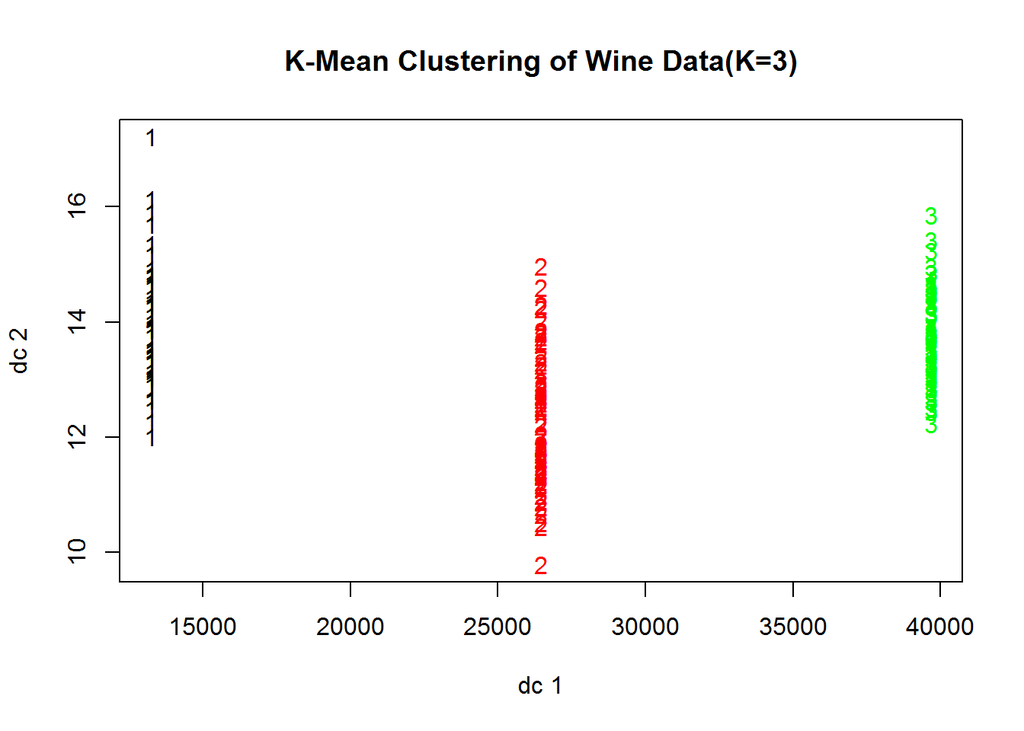

```r
#Define the distance function
distance <- function (k,m){
  d = sqrt(sum((k[1,]-m[1,])^2))
  return(d)
}

#Define a function that determines the cluster of each data point
cluster_n <- function (x,y) {
  n = nrow(y)
  dis = c()
  for (i in 1:n){
    dis[i] = distance(x,y[i,])
  }
  number = match(min(dis),dis)
  return (number)
}

##### Install packages first
#install.packages('rattle')
#install.packages('fpc')
data(wine, package="rattle")
library('fpc')
wine=wine[,-1]

#Assign the three centroids and initialize the convergence and iteration values
cent <- wine[c(1,89,178),]
convergence1 = FALSE
convergence2 = FALSE

#Iterate the K-mean Algorithm until the clusters converge or 200 ietrations
counter = 0
while (!convergence1 & !convergence2) {
  counter = counter + 1
  #reset cluster index of each data point
  index = c()

  #assign each data point an index that matches the closest centre
  n_wine=nrow(wine)
  for(j in 1:n_wine){
    index[j] = cluster_n(wine[j,],cent)
  }

  #Extract the data in each cluster and group them
  wine[,"index"] <- index
  cluster_1 = subset (wine, index==1)
  cluster_2 = subset (wine, index==2)
  cluster_3 = subset (wine, index==3)

  #recalculate the centroids
  center1_old <- cent[1,]
  center2_old <- cent[2,]
  center1=colMeans(cluster_1)
  center2=colMeans(cluster_2)
  center3=colMeans(cluster_3)

  #Determine convergence by checking if the centroids still change
  convergence1 <- all(center1_old == center1)
  convergence2 <- all(center1_old == center1)


  cent<-rbind(center1,center2,center3)
  cent<-data.frame(cent)
  #print(counter)
  if (counter > 200) break
}

#Visualize the clusters
plotcluster(wine,index,main="K-Mean Clustering of Wine Data(K=3)")
```

As can be seen from the plot, the clusters are well separated.

To quantify the degree of correspondance of the classified clusters to the types of wine, we can calculate the number of wines we have successfully designated the ‘right’ index.

This can be done throught the following code:

```r
#Extract information of the type of the wine
data(wine, package="rattle")
type <- wine[,1]

#Exchange the indices so that they match the type labelling number
index[index==2]<-4
index[index==3]<-2
index[index==4]<-3

#Accuracy is then calculated as ratio of the number of 'correct' indices and that of the total indices
accuracy <- length(index[index==type])/length(index)
print(paste("The accuracy of the algorithm in matching type is",accuracy))
```

```
## [1] "The accuracy of the algorithm in matching type is 0.702247191011236"
```

The ‘scale’ function first subtract each column of data by its mean and then divide each column by its standarded deviation. Effectively, this normalizes the elements of each column so as to remove the dominance by columns with large values. The results are as shown below:

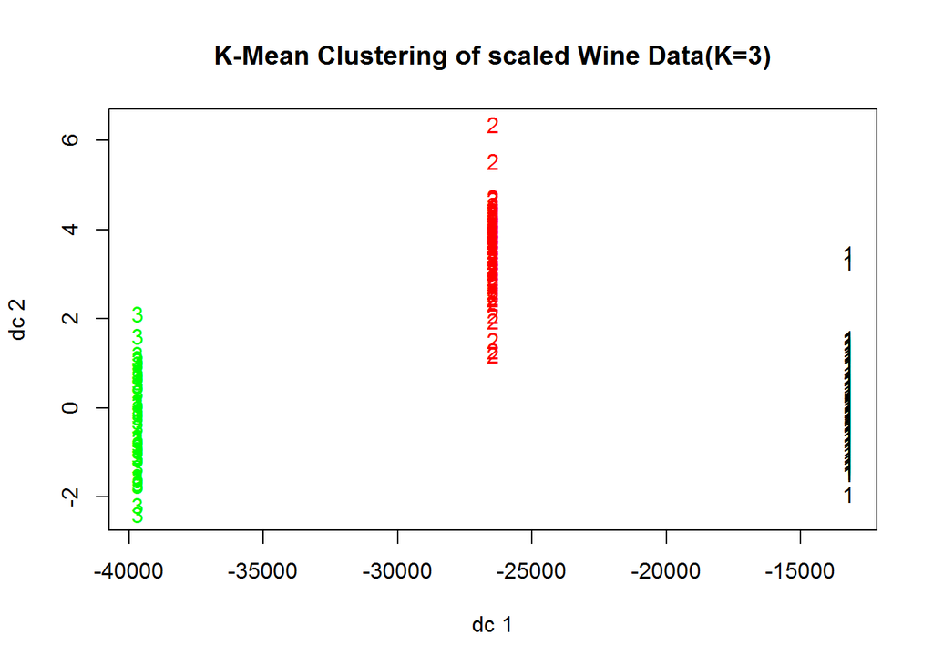

```r
data(wine, package="rattle")
library('fpc')
wine <- wine[,-1]
wine <- scale(wine)
wine <- data.frame(wine)

#Assign the three centroids and initialize the convergence and iteration values
cent <- wine[c(1,89,178),]
convergence1 = FALSE
convergence2 = FALSE

#Iterate the K-mean Algorithm until the clusters converge or 200 ietrations
counter = 0
while (!convergence1 & !convergence2) {
  counter = counter + 1
  #reset cluster index of each data point
  index = c()

  #assign each data point an index that matches the closest centre
  n_wine=nrow(wine)
  for(j in 1:n_wine){
    index[j] = cluster_n(wine[j,],cent)
  }

  #Extract the data in each cluster and group them
  wine[,"index"] <- index
  cluster_1 = subset (wine, index==1)
  cluster_2 = subset (wine, index==2)
  cluster_3 = subset (wine, index==3)

  #recalculate the centroids
  center1_old <- cent[1,]
  center2_old <- cent[2,]
  center1=colMeans(cluster_1)
  center2=colMeans(cluster_2)
  center3=colMeans(cluster_3)

  #Determine convergence by checking if the centroids still change
  convergence1 <- all(center1_old == center1)
  convergence2 <- all(center1_old == center1)


  cent<-rbind(center1,center2,center3)
  cent<-data.frame(cent)
  #print(counter)
  if (counter > 200) break
}

#Visualize the clusters
plotcluster(wine,index,main="K-Mean Clustering of scaled Wine Data(K=3)")
```

The accuracy with the scaled data is:

```r
#Extract information of the type of the wine
data(wine, package="rattle")
type <- wine[,1]

#Accuracy is then calculated as ratio of the number of 'correct' indices and that of the total indices
accuracy <- length(index[index==type])/length(index)
print(paste("The accuracy of the algorithm in matching type is",accuracy))
```

```
## [1] "The accuracy of the algorithm in matching type is 0.960674157303371"
```

From this result, it is clear that the scaled data performs much better with greater accuracy.

The same method is applied on the ‘iris’ data, which describe measurements from several flowers from three different species.

For the unscaled data, the results are as follows:

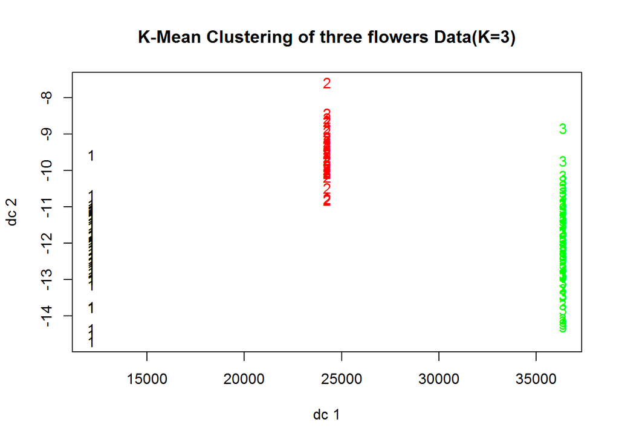

The accuracy can be calculated by modifying the previous code:

```r
#Extract information of the type of the wine
data(iris)
type <- iris[,5]

#Convert the names of the flowers to indices
type <- as.numeric(type)

#Accuracy is then calculated as ratio of the number of 'correct' indices and that of the total indices
accuracy <- length(index[index==type])/length(index)
print(paste("The accuracy of the algorithm in matching type is",accuracy))
```

```
## [1] "The accuracy of the algorithm in matching type is 0.873333333333333"
```

Similarly, we can perform the above clustering with scaled data of iris. The results are as shown:

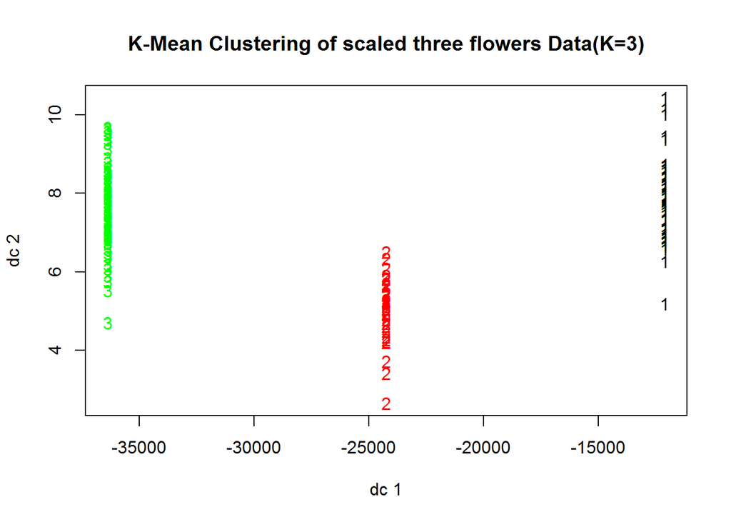

```
## [1] "The accuracy of the algorithm in matching type is 0.866666666666667"
```

In this case, k-means algorithm still works decently but the accuracy decreses with scaled data.